# Practical Machine Learning Assignment

PT

Sunday, June 21, 2015

**OVERVIEW**

The objective of this study is to use data collected from accelerometers on the belts, forearms, arms and dumbbells of six participants to predict the manner in which they did exercise.

The data is collected from the following source http://groupware.les.inf.puc-rio.br/har

**DESCRIPTION OF STUDY**

Six young healthy participants were asked to perform one set of 10 repetitions of the Unilateral Dumbbell Biceps Curl in five different fashions: exactly according to the specification (Class A), throwing the elbows to the front (Class B), lifting the dumbbell only halfway (Class C), lowering the dumbbell only halfway (Class D) and throwing the hips to the front (Class E).

Class A corresponds to the specified execution of the exercise, while the other 4 classes correspond to common mistakes. Participants were supervised by an experienced weight lifter to make sure the execution complied to the manner they were supposed to simulate. The exercises were performed by six male participants aged between 20-28 years, with little weight lifting experience. We made sure that all participants could easily simulate the mistakes in a safe and controlled manner by using a relatively light dumbbell (1.25kg).

Read more: http://groupware.les.inf.puc-rio.br/har#weight_lifting_exercises#ixzz3diB70100

**DATA EXTRACTION AND CLEANSING**

The test and training datasets were downloaded. Preliminary examination revealed a high number of sparsely populated variables, and in particular variables with a high number of NAs in the rows. These were eliminated, resulting in 60 variables.

```r
#1. Read in the files specified

require(caret)
```

```r
trainf <-tempfile()
trainUrl <- "http://d396qusza40orc.cloudfront.net/predmachlearn/pml-training.csv"
download.file(trainUrl,trainf)

testf <-tempfile()
testUrl <- "http://d396qusza40orc.cloudfront.net/predmachlearn/pml-testing.csv"
download.file(testUrl,testf)

traind <-read.csv(trainf, na.strings = c("NA","#DIV/0!", " "), header = TRUE)
testd <-read.csv(testf, na.strings = c("NA","#DIV/0!", " "), header = TRUE)

#Find NAs per column

sumna <-apply(traind, 2, function(x) length(which(is.na(x)))/length(x))
##Look at values

unique(sumna)
```

```
##  [1] 0.0000000 0.9798186 0.9809398 1.0000000 0.9797676 0.9793089 0.9832841
##  [8] 0.9833860 0.9798695 0.9832331 0.9795638 0.9794109 0.9795128 0.9793599
## [15] 0.9835898 0.9836408 0.9835389
```

```r
##Conclusion that columns that contain NAs do so in more than 90% of the rows.
##Remove these

reducetrain <-traind[,(sumna <0.9)]
```

**TREATMENT OF ZERO COVARIATES**  
As a next step in data cleansing, the dataset was examined for zero covariates. One zero covariate was uncovered and this was removed from the model

```r
nsv <- nearZeroVar(reducetrain,saveMetrics=TRUE)

##Based on this, we can discard the new_window metric

reducetrain <-reducetrain[,nsv$nzv==FALSE]
```

**EXAMINATION OF REMAINING VARIABLES**  
Upon examination of the remaining variables, it was clear that several of them have no predictive power, so these were removed.

- X
- user_name
- raw_timestamp_part_1
- raw_timestamp_part_2
- cvtd_timestamp
- num_window

**SPLITTING THE DATASET**  
The training dataset previously downloaded and cleansed was then further split into a training and test dataset to expore different models.

```r
set.seed(1969)
inTrain <-createDataPartition(y=reducetrain$classe, p=0.6, list=FALSE)
train_tr <- reducetrain[inTrain,]
train_ts <-reducetrain[-inTrain,]
```

This resulted in 2 datasets. One for building the model and one for validating the model.

**MODEL SELECTION**

I tested a generalized boosted model (gbm) a random forest (rf) a linear discriminant analysis model (lda) and a linear support vector machine (LinearSVC). Inspiration for the model choice came in part from the following reference:

http://scikit-learn.org/stable/tutorial/machine_learning_map/

**OUT-OF-SAMPLE ERROR AND MODEL CHOICE**

The models were trained and used to predict outcomes for classe based on the test data partition.

```r
pgbm <- predict(traingbm, train_ts)
prf <- predict(trainrf, train_ts)
plda <- predict(trainlda, train_ts)
psvc <- predict(trainsvc, train_ts)
```

The clear candidate was the random forest. The accuracy table from the confusion matrix also gave me confidence in choosing this model.

```r
accuracy_rf <- confusionMatrix(train_ts$classe, prf)
accuracy_rf$table
```

```
##           Reference
## Prediction    A    B    C    D    E
##          A 2231    1    0    0    0
##          B    5 1508    3    0    2
##          C    0    1 1364    3    0
##          D    0    0    7 1278    1
##          E    0    1    1    3 1437
```

**CROSS VALIDATION**  
According to http://www.stat.berkeley.edu/~breiman/RandomForests/cc_home.htm, the random forest model does not need additional cross-validation, however it is insightful to cross-validate all models across the board to examine if the chosen model might have been different with data sampled differently.

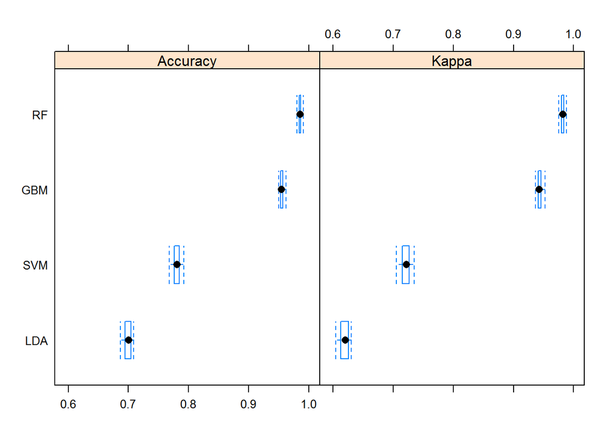

```r
resamps <- resamples(list(GBM = traingbm,
                          SVM = trainsvc,
                          RF = trainrf,
                          LDA = trainlda))
bwplot(resamps)
```

Here again, Random Forest clearly outperforms the other models.

**CONCLUSION**

It is abundantly clear that, even with resampling, random forest remains the model of choice for predicting the manner in which exercises were performed based on sensor data.